# Line Intercept Riparian Survey 4 Hydrophytes and More

Oliver Franklin

2025-12-04

# Data import

For this script we import the tidied dataframe generated by the Data Wrangling script, which was exported to your output folder.

Here we further explore the data collected in the line intercept survey methodology, specifically:

- Hydrophytic vegetation;
- Invasive vegetation; and
- Overhanging vegetation.

## Hydrophytic Vegetation

Hydrophytic vegetation can be a useful indicator of soil moisture conditions, and may be especially useful in monitoring restoration actions that are anticipated to alter groundwater levels, durations of soil saturation, etc. Some general considerations are:

- Plants would only be expected to reflect changes in soil moisture regime if changes occur within the rooting zone.
- Plants integrate environmental conditions over various timescales, and individual plants may tolerate a range of conditions. These ‘delays’ in response can be useful: if you did not have an opportunity to collect enough ‘before restoration’ data, the vegetation surveyed immediately after restoration implementation can still represent the conditions ‘before’ restoration. Note that for improved statistical and inferential power, we always recommend two or more years of ‘before’ data. But if one year of last-minute data is all that is possible, it can still provide highly useful for interpreting changes.
- The hydrophytic categories (obligate, facultative; wetland vs. upland) are typically applied at the species level. However, because plants have astounding ecological plasticity, various ecotypes can exist such that a member of a particular species may be a hydrophyte in some habitats or regions, and not in others. As such, consult a local expert or use local guidance wherever possible.

In the data below, we focus on the categories OBL (obligate wetland), FACW (facultative wetland), and FAC (facultative). Many would consider all of these categories as hydrophytic vegetation, some might have more strict criteria. By generating a number of metrics, we will leave it to you to decide which categorisations are most appropriate for you. For example, you may have an abundance of FAC plants that you would not consider useful indicators of floodplain wetland conditions, and you may prefer to base your interpretation of changing soil moisture conditions on the OBL and FACW plants only.

#### A note on transect boundaries

Since many restoration actions that alter soil moisture conditions in a floodplain might also influence inundation and scour, it is important to consider whether your transect locations have shifted. For example, if you began your transects at a certain scour line, or wetted edge, or bankfull mark, and your restoration causes flooding of a larger area, we might expect these reference points to also move. It may have been possible to identify or install fixed benchmarks to measure to or from, or you may have measured cross-sections of the aquatic habitat along the same locations as your vegetation transects; both approaches should allow you to interpret observed changes in your vegetation transects without complication.

However, if you do not have permanent benchmarks, the potential movement of the transect must be considered in your interpretation of changes in vegetation, particularly for the metrics that relate to the distance of hydrophytes along the transect. One potential observed pattern might be a reduction in the abundance of hydrophytes in the first couple of years after restoration, followed by an increase beyond that time. This could be explained as the result of (e.g.,) hydrophytes closer to the restored channel being washed away in the first couple of years, while plants farther from the stream become established over several years in reaction to the new soil moisture regime. We strongly recommend considering the potential outcomes, and the mechanisms that cause them, prior to interpreting any of the metrics below.

### Relative abundance of hydrophytes

Just like we did in ‘Line Intercept Riparian Survey 2 Relative Abundance’, we will start by considering the composition of plants, distinguishing this from the density of plants. Only this time, we are focusing not on the particular species, but on their status as hydrophytes. As before, we are calculating the relative abundance at each transect, then computing the mean and sd for the site that year. We will display the summary statistics in the below table, and a plot of the values per transect follows.

| Site | year | BankGroup | hydro_group | mean_rel_abundance | sd_rel_abundance | n_transects |
| --- | --- | --- | --- | --- | --- | --- |
| CONTROL | 2024 | Combined | OBL | 0.1626689692029733 | 0.1591015727891393 | 10 |
| CONTROL | 2024 | Combined | OBL_FACW | 0.7931737020125074 | 0.1244527702098527 | 10 |
| CONTROL | 2024 | Combined | OBL_FACW_FAC | 0.9968701653698915 | 0.009897406130813392 | 10 |
| CONTROL | 2026 | Combined | OBL | 0.1629665978153239 | 0.1711794815055922 | 10 |
| CONTROL | 2026 | Combined | OBL_FACW | 0.7882240062041176 | 0.154758117835826 | 10 |
| CONTROL | 2026 | Combined | OBL_FACW_FAC | 0.9968475548763657 | 0.009968906789375653 | 10 |
| Turkey Brook | 2024 | Combined | OBL | 0.07139184807418997 | 0.07565902512701995 | 10 |
| Turkey Brook | 2024 | Combined | OBL_FACW | 0.8237769990541545 | 0.1108668280562307 | 10 |
| Turkey Brook | 2024 | Combined | OBL_FACW_FAC | 0.9994336745807013 | 0.001790878221833583 | 10 |
| Turkey Brook | 2026 | Combined | OBL | 0.1247121493476442 | 0.1317664946774826 | 10 |

[output cut: 2 more lines]

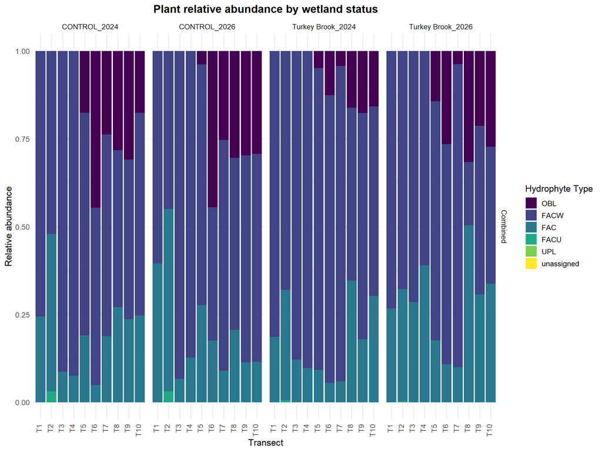

### Cover density of hydrophytes

As we did for cover density in the previous script, we need to consider whether you want to include the non-plant data and the overhanging extents of plants. Our defaults will be to exclude both, but you can change this below.

```r
include_non_plants <- FALSE   # change to TRUE to keep the non-plant occurrences (Plant_codes starting with "!")
include_overhanging <- FALSE   # change to TRUE to keep overhanging extents of vegetation (negative Start_location values)
```

The table below displays the mean and sd values for the reach (separated by bank if you previously specified that) of the cover density of the three hydrophyte categories in metres of hydrophyte per metre of transect. Some of these values may be greater than 1.0 due to the multiple height classes involved, overlap of plants, and the potential inclusion of vegetation that overhangs the channel.

| Site | year | BankGroup | Mean_OBL | SD_OBL | Mean_OBL_FACW | SD_OBL_FACW | Mean_OBL_FACW_FAC | SD_OBL_FACW_FAC |
| --- | --- | --- | --- | --- | --- | --- | --- | --- |
| CONTROL | 2024 | Combined | 0.482 | 0.538 | 1.895 | 0.782 | 2.386 | 0.976 |
| CONTROL | 2026 | Combined | 1.099 | 1.244 | 3.765 | 2.348 | 4.719 | 2.612 |
| Turkey Brook | 2024 | Combined | 0.229 | 0.249 | 2.406 | 0.426 | 2.94 | 0.459 |
| Turkey Brook | 2026 | Combined | 0.267 | 0.291 | 1.272 | 0.552 | 1.758 | 0.699 |

### Hydrophte Distance

The next table shows the mean across all transects of the farthest hydrophyte occurrence from the start of each transect (bankfull/wetted edge/scour line etc.). The intention of this metric is to track stream-driven changes in soil moisture conditions that might decrease in magnitude with distance from the channel. For example, restoration actions that reconnect the floodplain might be expected to increase the elevation of groundwater in the floodplain for a sufficient duration to alter the plant community close to the stream, but this effect might diminish with distance from the source of water.

This metric may be useful for communication given the ease of interpreting ‘wetland vegetation *x* m farther from the stream’, but consider the potential difficulties associated with shifting transect locations if the channel edge shifts. In general, we would expect the density and abundance of hydrophytes to capture the stream-driven changes shown below, but the distance component may have particular interest if relatively novel restoration techniques are applied (e.g. Beaver Activity Mimicking Structures).

| Site | year | BankGroup | Mean_OBL | SD_OBL | Mean_OBL_FACW | SD_OBL_FACW | Mean_OBL_FACW_FAC | SD_OBL_FACW_FAC |
| --- | --- | --- | --- | --- | --- | --- | --- | --- |
| CONTROL | 2024 | Combined | 12.867 | 11.709 | 24.189 | 4.101 | 25.769 | 2.263 |
| CONTROL | 2026 | Combined | 14.975 | 14.956 | 30 | 0 | 30 | 0 |
| Turkey Brook | 2024 | Combined | 16.26 | 14.336 | 30 | 0 | 30 | 0 |
| Turkey Brook | 2026 | Combined | 16.751 | 14.571 | 22.913 | 7.793 | 25.177 | 7.366 |

When interpreting hydrophytic vegetation, particularly if you are seeing their presence more distant from the stream channel, consider whether driving factors may be present that are distinct from those of the focal channel (e.g., isolated seeps or depressions in the riparian area). When we consider the above metrics, particularly the maximum extent of hydrophytic vegetation from the channel, be cautious about attributing the observed changes to your restoration actions. Although the presence of an isolated seep might not necessarily impact the *change* in these metrics across time, it could still be misleading when drawing conclusions.

## Invasive Vegetation

### Invasive Relative Abundance

Now we will take a look at the relative abundance, and the cover density, of plants that you labelled as invasive. The next table provides the mean and sd values of the relative abundance of plants labelled as invasive. Note that these means are taken across all transects that have any plants and are not weighted by the density of vegetation present on those transects.

| Site | year | BankGroup | mean_rel.abundance_invasive | sd_rel.abundance_invasive | n_transects |
| --- | --- | --- | --- | --- | --- |
| CONTROL | 2024 | Combined | 0.572 | 0.227 | 10 |
| CONTROL | 2026 | Combined | 0.507 | 0.254 | 10 |
| Turkey Brook | 2024 | Combined | 0.693 | 0.167 | 10 |
| Turkey Brook | 2026 | Combined | 0.486 | 0.2 | 10 |

The following figure shows the transect values for the invasive status.

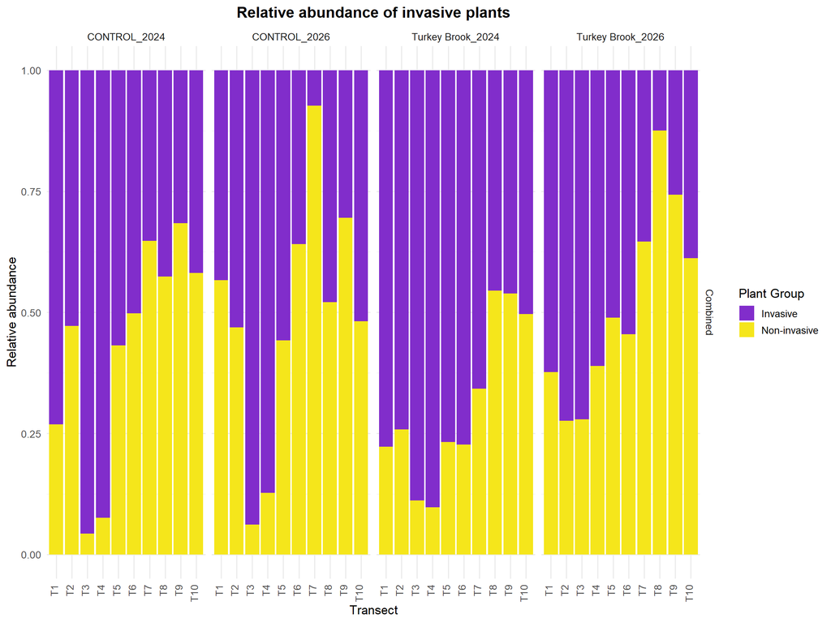

### Invasive Cover Density

As we did for cover density previously, we need to consider whether you want to include the non-plant data and the overhanging extents of plants. Our defaults will be to exclude both, but you can change this below.

```r
include_non_plants <- FALSE   # change to TRUE to keep the non-plant occurrences (Plant_codes starting with "!")
include_overhanging <- FALSE   # change to TRUE to keep overhanging extents of vegetation (negative Start_location values)
```

Our next table dispalys the mean and sd value for invasive vegatation cover density (m per m of transect).

| Site | year | BankGroup | mean_density_invasive | sd_density_invasive | n_transects |
| --- | --- | --- | --- | --- | --- |
| CONTROL | 2024 | Combined | 1.262 | 0.415 | 10 |
| CONTROL | 2026 | Combined | 2.105 | 1.287 | 10 |
| Turkey Brook | 2024 | Combined | 1.979 | 0.3 | 10 |
| Turkey Brook | 2026 | Combined | 0.751 | 0.272 | 10 |

# Overhanging Vegetation

The next table provides metrics regarding the overhanging vegetation that may have been present at your site. The overhang metrics relate to only the extent of vegetation that extends outside of your transect start location (i.e., the part above the channel, not including the rest of that particular plant). Note that overhanging vegetation can be associated with any height class plant, such that any one transect can have multiple layers of overhanging vegetation, though recall that we only record overhanging vegetation that extends to within 1 m vertically of bankfull elevation.

| Site | year | BankGroup | Mean overhang across all transects | SD overhang across all transects | Mean overhang where present | SD overhang where present | Proportion transects with overhang |
| --- | --- | --- | --- | --- | --- | --- | --- |
| CONTROL | 2024 | Combined | 1.625 | 1.684 | 2.032 | 1.644 | 0.8 |
| CONTROL | 2026 | Combined | 0.73 | 1.004 | 1.216 | 1.05 | 0.6 |
| Turkey Brook | 2024 | Combined | 3.2 | 2.781 | 4 | 2.507 | 0.8 |
| Turkey Brook | 2026 | Combined | 3.2 | 2.781 | 4 | 2.507 | 0.8 |

The next table also provides some summary information regarding the types of vegetation that overhang the channel - potentially useful in understanding which vegetation is most successful in this role for your site.

| Site | year | Species | BankGroup | Total reach magnitude (m) of overhang | Nr transects overhanging | Mean overhang (m) where present | SD overhang where present | Probabilty of overhang, if within 2 horizontal m |
| --- | --- | --- | --- | --- | --- | --- | --- | --- |
| Turkey Brook | 2024 | ALNUS | Combined | 13 | 4 | 2.6 | 2.074 | 1 |
| Turkey Brook | 2026 | ALNUS | Combined | 13 | 4 | 2.6 | 2.074 | 1 |
| Turkey Brook | 2024 | PHALARU | Combined | 11 | 5 | 1.833 | 0.753 | 0.5 |
| Turkey Brook | 2026 | PHALARU | Combined | 11 | 5 | 1.833 | 0.753 | 0.5 |
| CONTROL | 2024 | PHALARU | Combined | 7.155 | 5 | 1.193 | 0.503 | 0.5 |
| Turkey Brook | 2024 | LONIINV | Combined | 5 | 2 | 2.5 | 2.121 | 1 |
| Turkey Brook | 2026 | LONIINV | Combined | 5 | 2 | 2.5 | 2.121 | 1 |
| CONTROL | 2024 | ALNUS | Combined | 3.883 | 4 | 0.777 | 0.972 | 0.8 |
| CONTROL | 2026 | SALIHOO | Combined | 3.498 | 2 | 1.749 | 0.054 | 0.5 |
| Turkey Brook | 2024 | SALISCO | Combined | 3 | 2 | 1.5 | 0.707 | 0.667 |

[output cut: 7 more lines]

In the above table we have speculatively included some metrics that might be of interest. The following metrics are considered to integrate both information about that species’ abundance and that species’ tendency to overhang:

- Total reach magnitude of overhang (sum of total distance in the reach that this species overhangs),
- Number of transects overhanging (by this particular species), and
- Mean and SD of overhang where present (where the species is both present and overhanging).

These may be of use in determining which species can fill this role in your particular habitat or area.

In contrast, we generated a metric that attempts to isolate the tendency, at your site, of that given plant species to overhang the stream channel:

- Probability of overhang. This metric is the probability (0 to 1) that, if this plant species is present at your site within 2 horizontal metres of the channel, it will also be overhanging the channel. This metric might be useful in adaptive management of riparian planting, to inform which plants should be favoured closer to the channel, if providing overhanging vegetation to the aquatic ecosystem is a priority.

# Inferential Tests

If you have a control or reference site and multiple years of data, we can apply inferential statistical tests to see if the observed changes are likely to be due to chance variability, or are consistent with the expected effects of your restoration actions. We will test whether there are statistically significant changes in:

- Relative abundance and cover density of the three hydrophte groups;
- Relative abundance and cover density of invasive vegetation; and
- Extent of overhanging vegetation.

You will be familiar with p values of 0.05 (observed result expected just due to chance 1 in 20 times) and we will use p=0.05 as our cut-off here. However, depending on your adaptive management plans, you may be willing to accept different levels of certainty, and p values of 0.1 are not unheard of in restoration projects. This all depends on the risk tolerance of you and your team, and should be established before conducting analyses.

Consistent with our prior inferential analyses, we will use Beta regressions for the relative abundance data and generalised linear models with Gamma distributions for the cover density data and for the overhanging vegetation. Although both cover density and overhanging vegetation may feature many zero values, we are comfortable adjusting these to 1 mm rather than introducing the user to hurdle models. This small adjustment could be considered to reflect real vegetation values that would not have been recorded in the field (thus being assigned zero ‘incorrectly’).

*NB* We provide these tests as a general framework, and caution against using them if you do not understand what the models are doing. We may not have an opportunity to refine them (changes in government priorities) but consider them a useful placeholder for now. We will apply these models based on what we expect the data to look like, however, actual data collected across a variety of ecosystems and stages of recovery might be very different, so we caution against taking the results at face value. If in doubt, our best advice is to rely on your own (and your restoration partners’) interpretation of the raw data and the figures we have already presented above.

The tests are carried out below, after we specify the before and after data that you wish to compare.

#### Before / After Years

Enter your before and after years in the below code, you may have more than one year in each category. Remember that these should balance (equal number of years before as after), but they need not be consecutive years. If you do not have balanced data (e.g., only one year was possible before project implementation) be very cautious in running and interpreting the tests. You could select only a subset of your data to keep the comparison balanced, but if you do this for more than one set of dates you must account for the multiple comparisons inflating the likelihood of a Type I error (false positive).

```r
# Define "Before" and "After" years
before_years <- c(2024) #add more years inside brackets if needed, e.g. 'c(2024, 2025, 2026)'
after_years <- c(2026) #add more years inside brackets if needed, e.g. 'c(2027, 2029, 2036)'
```

### Hydrophyte Relative Abundance: Beta Regression

Because of the potential number of model outputs and diagnostic figures generated with this Beta regression, we will suppress them from being displayed. Instead, we generate a summary table that only displays the Site*Time interaction model results, and we will export the full model results to your output folder. We do this because many people using this code will not want to interpret these models. If you do wish to interpret them, you should review the full models and the diagnostics (instructions within code).

Please note that the interaction terms will only be displayed for models that were successfully run - if there were no Site x Time interactions, if there were too few observations, or if there were too little variation in the response variable, then those models will not be generated. This might occur relatively frequently for these types of relative abundance data because the hydrophyte categorisation can easily result in transects with relative abundance values of either ‘0’ or ‘1’.

| Hydro_Group | Bank | Estimate | Std_Error | z_value | p_value |
| --- | --- | --- | --- | --- | --- |
| OBL | Combined | -0.154 | 0.656 | -0.234 | 0.815 |
| OBL_FACW | Combined | 0.56 | 0.424 | 1.321 | 0.187 |
| OBL_FACW_FAC | Combined | -0.032 | 0.524 | -0.061 | 0.952 |

### Hydrophyte Cover Density: GLM - Gamma

| Hydro_Group | Bank | Estimate | Std_Error | t_value | p_value |
| --- | --- | --- | --- | --- | --- |
| OBL_cover | Combined | 0.674 | 0.699 | 0.965 | 0.341 |
| OBL_FACW_cover | Combined | 1.323 | 0.279 | 4.741 | 0 |
| OBL_FACW_FAC_cover | Combined | 1.196 | 0.256 | 4.67 | 0 |

### Invasive Vegetation Relative Abundance: Beta Regression

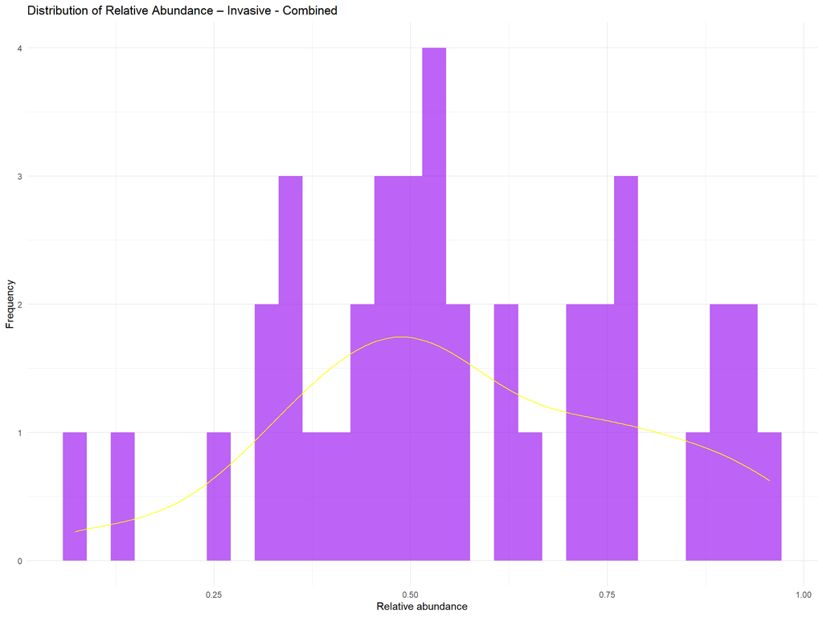

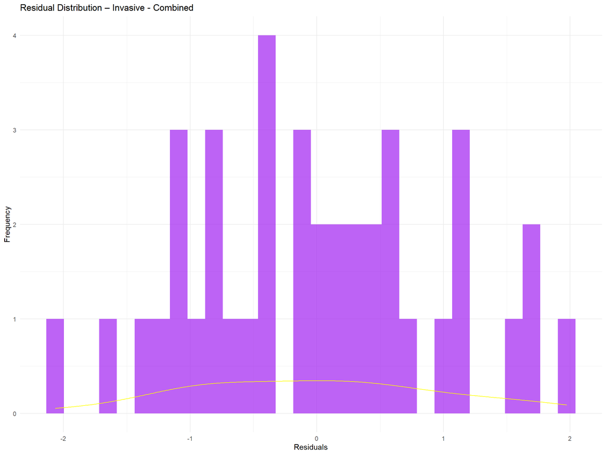

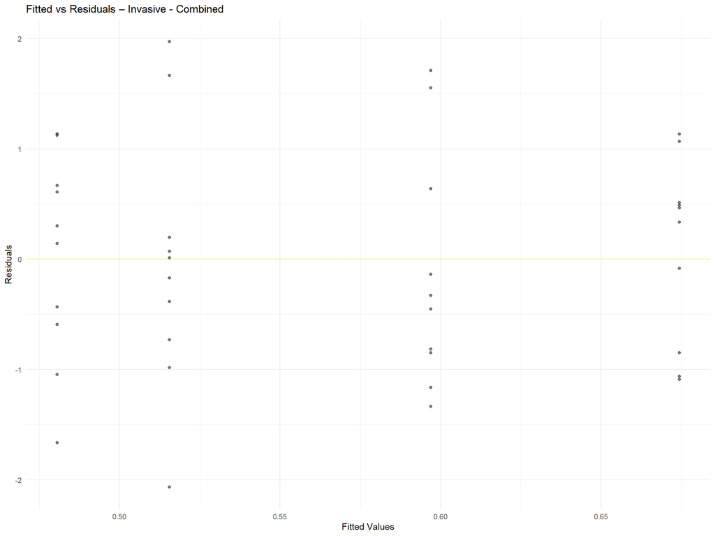

```
##
## Call:
## betareg(formula = rel_adj ~ Site * Time_Category, data = d_sub)
##
## Quantile residuals:
##     Min      1Q  Median      3Q     Max
## -2.3702 -0.7553 -0.0779  0.5212  2.3489
##
## Coefficients (mean model with logit link):
##                                      Estimate Std. Error z value Pr(>|z|)
## (Intercept)                           0.06241    0.26771   0.233    0.816
## SiteTurkey Brook                     -0.14027    0.37866  -0.370    0.711
## Time_CategoryBefore                   0.33050    0.38073   0.868    0.385
## SiteTurkey Brook:Time_CategoryBefore  0.47527    0.54157   0.878    0.380
##
## Phi coefficients (precision model with identity link):
##       Estimate Std. Error z value Pr(>|z|)
## (phi)   4.4399     0.9063   4.899 9.64e-07 ***
## ---
## Signif. codes:  0 '***' 0.001 '**' 0.01 '*' 0.05 '.' 0.1 ' ' 1
##
## Type of estimator: ML (maximum likelihood)
## Log-likelihood: 7.944 on 5 Df
## Pseudo R-squared: 0.1163
## Number of iterations: 20 (BFGS) + 2 (Fisher scoring)
```

### Invasive Vegetation Cover Density: GLM - Gamma

```
##
## Call:
## glm(formula = cover_adj ~ Site * Time_Category, family = Gamma(link = "log"),
##     data = df_b)
##
## Coefficients:
##                                      Estimate Std. Error t value Pr(>|t|)
## (Intercept)                            0.7448     0.1260   5.909 9.19e-07 ***
## SiteTurkey Brook                      -1.0298     0.1782  -5.778 1.38e-06 ***
## Time_CategoryBefore                   -0.5114     0.1782  -2.869  0.00685 **
## SiteTurkey Brook:Time_CategoryBefore   1.4794     0.2521   5.869 1.04e-06 ***
## ---
## Signif. codes:  0 '***' 0.001 '**' 0.01 '*' 0.05 '.' 0.1 ' ' 1
##
## (Dispersion parameter for Gamma family taken to be 0.1588563)
##
##     Null deviance: 12.9022  on 39  degrees of freedom
## Residual deviance:  6.6572  on 36  degrees of freedom
## AIC: 73.761
##
## Number of Fisher Scoring iterations: 5
```

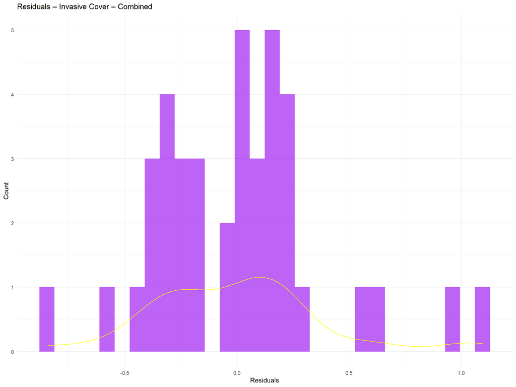

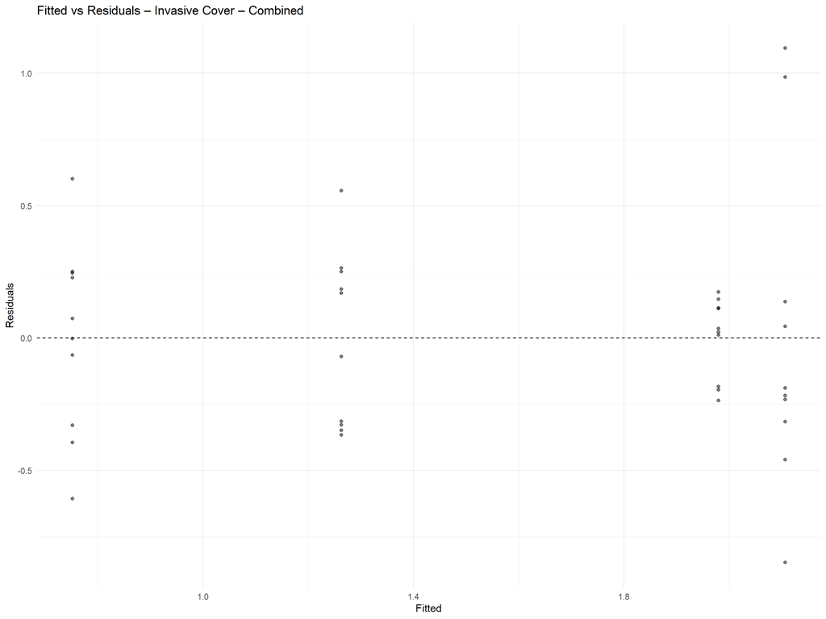

### Overhanging Vegetation Magnitude: GLM - Gamma

```
##
## Call:
## glm(formula = overhang_adj ~ Site * Time_Category, family = Gamma(link = "log"),
##     data = df_b)
##
## Coefficients:
##                                      Estimate Std. Error t value Pr(>|t|)
## (Intercept)                           -0.3139     0.3342  -0.939   0.3539
## SiteTurkey Brook                       1.4774     0.4726   3.126   0.0035 **
## Time_CategoryBefore                    0.8003     0.4726   1.693   0.0991 .
## SiteTurkey Brook:Time_CategoryBefore  -0.8003     0.6684  -1.197   0.2390
## ---
## Signif. codes:  0 '***' 0.001 '**' 0.01 '*' 0.05 '.' 0.1 ' ' 1
##
## (Dispersion parameter for Gamma family taken to be 1.116964)
##
##     Null deviance: 168.42  on 39  degrees of freedom
## Residual deviance: 155.71  on 36  degrees of freedom
## AIC: 93.505
##
## Number of Fisher Scoring iterations: 19
```

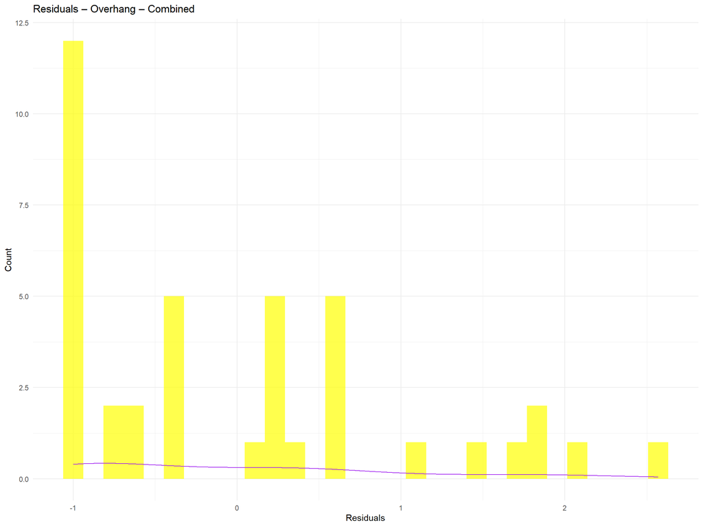

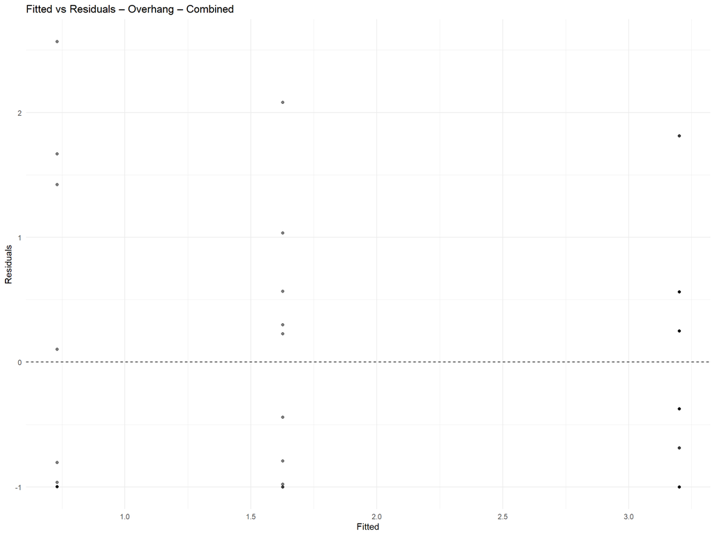

This is the end of the current script. Our next step will be to explore the patterns of vegetation by distance from the stream. This can be done with dissimilarity indices (e.g., as in Moving Split Window analyses) to objectively identify abrupt changes in species diversity as one progresses along the transect. It can also involve plots of various diversity indices and cover metrics by distance, to help to visually identify shifting patterns that may be associated with your restoration actions. *Unfortunately, at this point this further analyses is put on hold due to changing government priorities. We hope to return to this, and other restoration monitoring support, when ecosystems become a priority again*._